# rapor

**Yazar:** Eda Nur Serbest

**Tarih:** 27.05.2026

**Veri Kaynağı:** Kaggle - Student Sleep Patterns Dataset

|  | Student_ID | Age | Gender | University_Year | Sleep_Duration | Study_Hours | Screen_Time | Caffeine_Intake | Physical_Activity | Sleep_Quality | Weekday_Sleep_Start | Weekend_Sleep_Start | Weekday_Sleep_End | Weekend_Sleep_End |
| --- | --- | --- | --- | --- | --- | --- | --- | --- | --- | --- | --- | --- | --- | --- |
| 0 | 1 | 24 | Other | 2nd Year | 7.7 | 7.9 | 3.4 | 2 | 37 | 10 | 14.16 | 4.05 | 7.41 | 7.06 |
| 1 | 2 | 21 | Male | 1st Year | 6.3 | 6.0 | 1.9 | 5 | 74 | 2 | 8.73 | 7.10 | 8.21 | 10.21 |
| 2 | 3 | 22 | Male | 4th Year | 5.1 | 6.7 | 3.9 | 5 | 53 | 5 | 20.00 | 20.47 | 6.88 | 10.92 |
| 3 | 4 | 24 | Other | 4th Year | 6.3 | 8.6 | 2.8 | 4 | 55 | 9 | 19.82 | 4.08 | 6.69 | 9.42 |
| 4 | 5 | 20 | Male | 4th Year | 4.7 | 2.7 | 2.7 | 0 | 85 | 3 | 20.98 | 6.12 | 8.98 | 9.01 |

Yorum: Veri setinin ilk 5 satırı görüntülenmiş ve değişken yapısı incelenmiştir.

```
<class 'pandas.DataFrame'>
RangeIndex: 500 entries, 0 to 499
Data columns (total 14 columns):
 #   Column               Non-Null Count  Dtype
---  ------               --------------  -----
 0   Student_ID           500 non-null    int64
 1   Age                  500 non-null    int64
 2   Gender               500 non-null    str
 3   University_Year      500 non-null    str
 4   Sleep_Duration       500 non-null    float64
 5   Study_Hours          500 non-null    float64
 6   Screen_Time          500 non-null    float64
 7   Caffeine_Intake      500 non-null    int64
 8   Physical_Activity    500 non-null    int64
 9   Sleep_Quality        500 non-null    int64
 10  Weekday_Sleep_Start  500 non-null    float64
 11  Weekend_Sleep_Start  500 non-null    float64
 12  Weekday_Sleep_End    500 non-null    float64
 13  Weekend_Sleep_End    500 non-null    float64
dtypes: float64(7), int64(5), str(2)
memory usage: 54.8 KB
```

Yorum: Veri setinde toplam 500 gözlem ve 14 değişken bulunmaktadır. Değişken tipleri incelenmiştir.

```
Student_ID             0
Age                    0
Gender                 0
University_Year        0
Sleep_Duration         0
Study_Hours            0
Screen_Time            0
Caffeine_Intake        0
Physical_Activity      0
Sleep_Quality          0
Weekday_Sleep_Start    0
Weekend_Sleep_Start    0
Weekday_Sleep_End      0
Weekend_Sleep_End      0
dtype: int64
```

**Yorum:** Veri setinde eksik değer bulunmamaktadır. Bu nedenle eksik veri temizleme işlemi yapılmamıştır.

```
Gender
Male      186
Female    166
Other     148
Name: count, dtype: int64
```

Yorum: Cinsiyet değişkenindeki öğrenci sayıları incelenmiştir.

```
np.float64(5.362)
```

Yorum: Öğrencilerin ortalama uyku kalitesi hesaplanmıştır.

```
Korelasyon: -0.011092416590548144
```

Yorum: Çalışma süresi ile uyku süresi arasındaki korelasyon değeri -0.011 bulunmuştur. Bu değer sıfıra yakın olduğundan güçlü bir ilişki gözlenmemiştir.

```
Gender
Female    6.531928
Male      6.358065
Other     6.549324
Name: Sleep_Duration, dtype: float64
```

Yorum: Cinsiyet gruplarına göre ortalama uyku süreleri birbirine yakın bulunmuştur.

|  | Student_ID | Age | Sleep_Duration | Study_Hours | Screen_Time | Caffeine_Intake | Physical_Activity | Sleep_Quality | Weekday_Sleep_Start | Weekend_Sleep_Start | Weekday_Sleep_End | Weekend_Sleep_End |
| --- | --- | --- | --- | --- | --- | --- | --- | --- | --- | --- | --- | --- |
| count | 500.000000 | 500.00000 | 500.000000 | 500.000000 | 500.000000 | 500.000000 | 500.000000 | 500.000000 | 500.000000 | 500.000000 | 500.000000 | 500.000000 |
| mean | 250.500000 | 21.53600 | 6.472400 | 5.981600 | 2.525000 | 2.462000 | 62.342000 | 5.362000 | 11.166860 | 12.375860 | 6.929900 | 8.988100 |
| std | 144.481833 | 2.33315 | 1.485764 | 3.475725 | 0.859414 | 1.682325 | 35.191674 | 2.967249 | 5.972352 | 5.789611 | 1.183174 | 1.111253 |
| min | 1.000000 | 18.00000 | 4.000000 | 0.100000 | 1.000000 | 0.000000 | 0.000000 | 1.000000 | 1.080000 | 2.050000 | 5.000000 | 7.020000 |
| 25% | 125.750000 | 20.00000 | 5.100000 | 2.900000 | 1.800000 | 1.000000 | 32.750000 | 3.000000 | 6.087500 | 7.297500 | 5.900000 | 8.047500 |
| 50% | 250.500000 | 21.00000 | 6.500000 | 6.050000 | 2.600000 | 2.000000 | 62.500000 | 5.000000 | 10.635000 | 12.690000 | 6.885000 | 9.005000 |
| 75% | 375.250000 | 24.00000 | 7.800000 | 8.800000 | 3.300000 | 4.000000 | 93.250000 | 8.000000 | 16.152500 | 17.327500 | 7.972500 | 9.925000 |
| max | 500.000000 | 25.00000 | 9.000000 | 12.000000 | 4.000000 | 5.000000 | 120.000000 | 10.000000 | 21.930000 | 22.000000 | 8.980000 | 10.990000 |

Yorum: Sayısal değişkenlerin ortalama, standart sapma, minimum ve maksimum değerleri incelenmiştir. Öğrencilerin ortalama uyku süresi yaklaşık 6.47 saat olarak bulunmuştur.

```
University_Year
1st Year    6.493600
2nd Year    6.561832
3rd Year    6.489394
4th Year    6.324107
Name: Sleep_Duration, dtype: float64
```

Yorum: Sınıf düzeylerine göre ortalama uyku süreleri incelenmiştir. Sınıflar arasında büyük farklılık gözlenmemiştir.

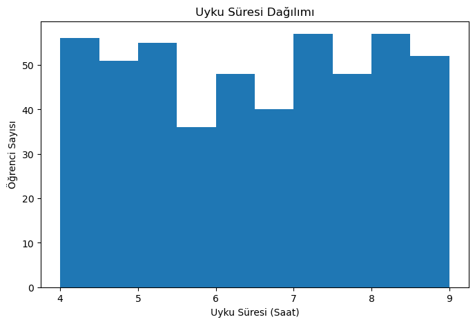

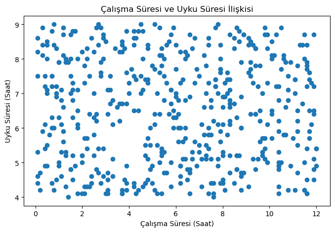

**Yorum:** Çalışma süresi ile uyku süresi arasında belirgin bir doğrusal ilişki gözlenmemiştir. Noktalar grafik üzerinde dağınık yapı göstermektedir.

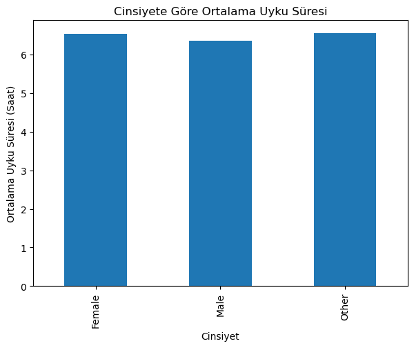

**Yorum:** Cinsiyet gruplarına göre ortalama uyku süreleri birbirine yakın bulunmuştur. Büyük bir farklılık gözlenmemiştir.

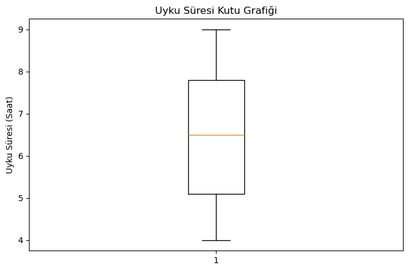

**Yorum:** Uyku sürelerinin medyan değeri yaklaşık 6.5 saat civarındadır. Belirgin aykırı değer gözlenmemiştir.

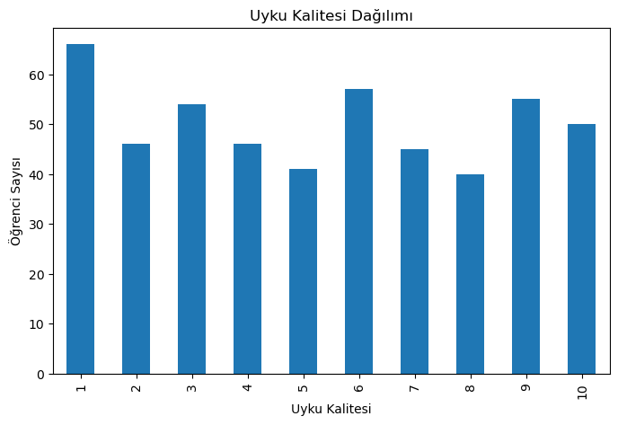

**Yorum:** Uyku kalitesi farklı seviyelerde dağılmıştır. Öğrenciler arasında değişkenlik olduğu görülmektedir.

# Öğrenci Uyku Verisi Analizi

## Veri Seti Hakkında

Bu çalışmada öğrencilerin uyku alışkanlıklarını içeren veri seti kullanılmıştır. Veri setinde toplam 500 gözlem ve 14 değişken bulunmaktadır.

Kullanılan değişkenler arasında yaş, cinsiyet, uyku süresi, çalışma süresi, ekran süresi, kafein tüketimi, fiziksel aktivite ve uyku kalitesi yer almaktadır.

## Yapılan Analizler

- Veri ön inceleme
- Tanımlayıcı istatistikler
- Uyku süresi dağılımı
- Çalışma süresi ve uyku süresi ilişkisi
- Korelasyon analizi
- Cinsiyete göre ortalama uyku süresi
- Uyku süresi kutu grafiği
- Uyku kalitesi dağılımı

## Bulgular

- Veri setinde toplam 500 gözlem ve 14 değişken bulunmaktadır.
- Öğrencilerin ortalama uyku süresi yaklaşık 6.47 saat olarak bulunmuştur.
- Çalışma süresi ile uyku süresi arasındaki korelasyon değeri -0.011 bulunmuş ve güçlü bir ilişki gözlenmemiştir.
- Cinsiyet gruplarına göre ortalama uyku süreleri birbirine yakın bulunmuştur.
- Uyku süreleri genel olarak 4 ile 9 saat arasında değişmektedir.

## Sonuç

Bu çalışmada öğrenci uyku verileri temel tanımlayıcı istatistikler ve grafikler yardımıyla incelenmiştir.

Yapılan analizler sonucunda öğrencilerin ortalama uyku süresinin yaklaşık 6.47 saat olduğu görülmüştür. Çalışma süresi ile uyku süresi arasında güçlü bir ilişki bulunmamıştır. Ayrıca cinsiyet grupları arasında ortalama uyku sürelerinin birbirine yakın olduğu belirlenmiştir.

Veri setinde eksik değer bulunmamış ve analizler doğrudan uygulanmıştır. Genel olarak öğrencilerin uyku sürelerinin 4 ile 9 saat arasında değiştiği görülmüştür.

## Kaynakça

- Student Sleep Patterns Dataset, https://www.kaggle.com/datasets/arsalanjamal002/student-sleep-patterns
- Pandas Documentation, https://pandas.pydata.org/
- Matplotlib Documentation, https://matplotlib.org/
- NumPy Documentation, https://numpy.org/